# Tutoriel Shiny Partie 4: Réactivité

Lise Vaudor

janvier 2018

# Réactivité : base

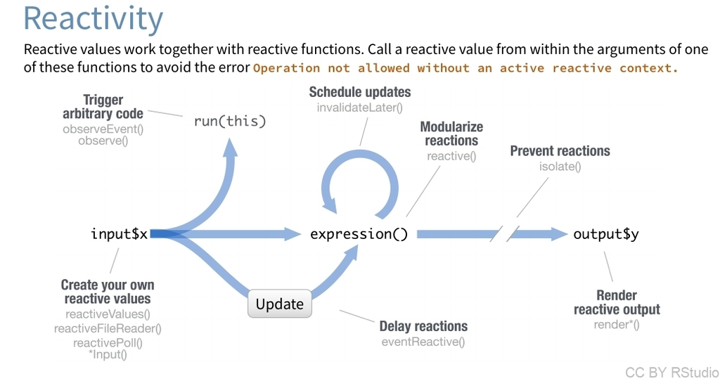

Dans sa version la plus simple, la chaîne de réactivité ressemble en fait à ceci :

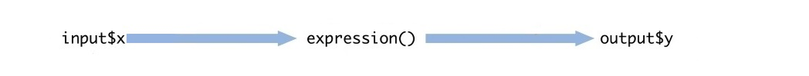

C’est, pour le moment, le seul type de réaction que l’on a abordé.

# Fournir des outputs réactifs

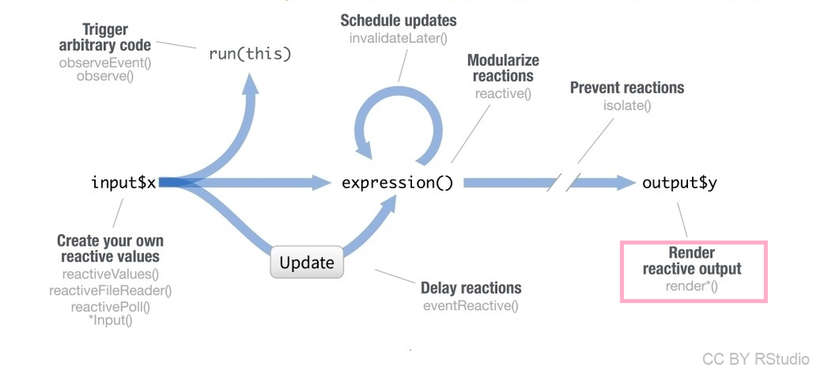

Pour rappel, voici comment l’on procède pour fournir un output réactif:

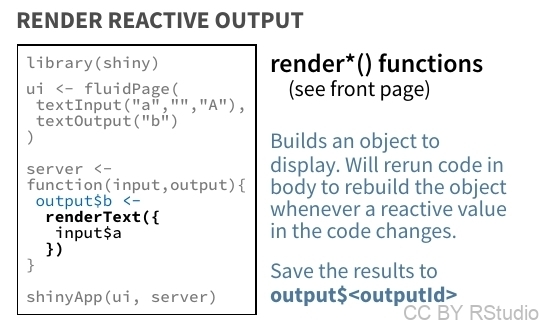

# Fournir des outputs réactifs - exemple (1)

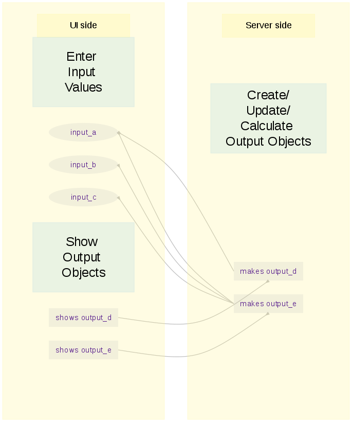

Observez le diagramme ci-contre, qui décrit un exemple de Shiny app, comprenant

- 3 inputs:
  - input_a
  - input_b
  - input_c
- 2 outputs:
  - output_d (qui dépend seulement de input_a)
  - output_e (qui dépend de input_a, input_b et input_c)

Je vais utiliser cet exemple pour illustrer le fonctionnement de la **réactivité** des Shiny apps.

# Fournir des outputs réactifs - exemple (2)

Commençons par simplifier et expliquer ce diagramme:

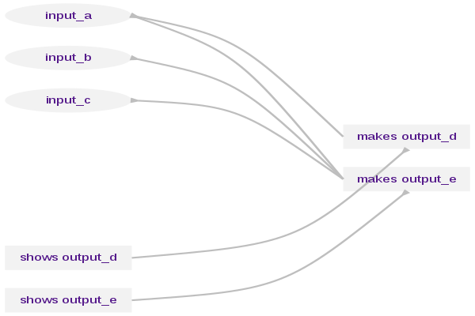

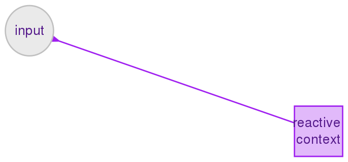

Observez le sens des flèches… Quand un input est modifié, il est **aspiré** par le contexte réactif… Et non l’inverse (il n’est **pas poussé** vers le contexte réactif)… Et, oui, la différence est subtile, mais importante pour la suite…

Observez maintenant la couleur de fond du contexte réactif. A gauche, tout est pour le moment en gris, mais par la suite on pourra observer plusieurs états pour les contextes réactifs:

- un état **attentif** (en orange)
- un état **en cours d’exécution** (en violet)
- un état **inerte** (en gris)

# Fournir des outputs réactifs - exemple (3)

Considérons une première “configuration” de Shiny app. (Avec l’exemple correspondant à droite).

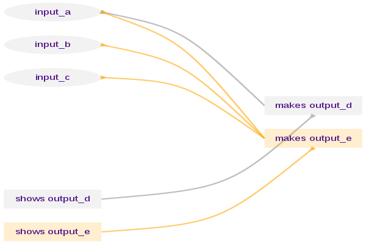

Ici, par défaut, seul **output_e** est affiché. Il est donc **attentif**, là où output_d est au contraire **inerte**.

Notez que quand l’utilisateur change de panel (en affichant “tab1” à la place de “tab2”), c’est au contraire output_d qui est attentif tandis que output_e est inerte…

ui

```r
  flowLayout(radioButtons("a","Word 1:", c("Hello","Greetings")),
             radioButtons("b","Word 2:", c("benevolent","great")),
             radioButtons("c","Word 3:", c("Master","Human"))),
  tabsetPanel(tabPanel("tab1",textOutput("d")),
              tabPanel("tab2",textOutput("e")),
              selected="tab2")
```

server

```r
  output$d <- renderText({Sys.sleep(1);paste(input$a,"!")})
  output$e <- renderText({Sys.sleep(1);paste(input$a,",",input$b,input$c,"!")})
```

[interactive chart not shown]

Ici j’ai fait en sorte de mettre le système en pause pendant une seconde (`Sys.sleep(1)`) pour que vous puissiez bien constater à quel moment le code dans les contextes réactifs est exécuté…

# Fournir des outputs réactifs - exemple (4)

Quand cette app est lancée, voilà donc ce qui se passe:

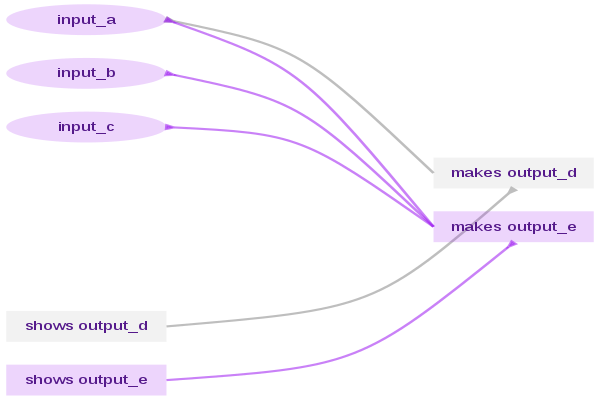

**shows output_e** est attentif, donc **makes output_e** est attentif, et aspire les 3 inputs (qui sont tous *nouveaux*) afin d’exécuter son code.

Par la suite, l’output qui est attentif est actualisé à chaque fois qu’un de ses inputs (ici par exemple input_b) est modifié…

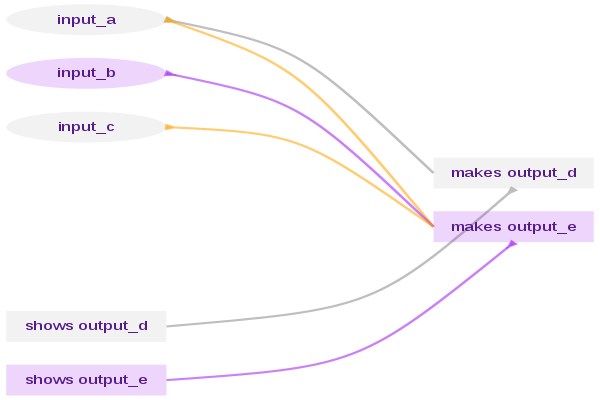

# Modulariser les réactions

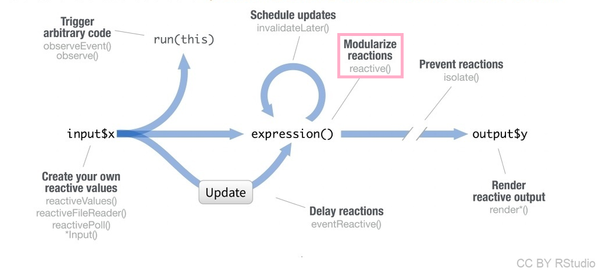

Vous avez déjà vu que les fonctions servent à “modulariser” du code (i.e., faire en sorte que certains morceaux de code soient “encapsulés” dans une structure qui permet de l’appeler et l’exécuter assez simplement…).

Les **reactives**, quant à elles, sont des fonctions qui permettent de modulariser du code réactif… L’usage de reactives est particulièrement utile lorsque certains morceaux de code sont utilisés par **plusieurs outputs à la fois**… Ainsi, comme l’écriture de fonctions en général, l’écriture de reactives permet d’éviter certaines redondances dans le code.

[figure not shown]

# Modulariser les réactions - exemple

Considérons cette nouvelle structure d’appli…

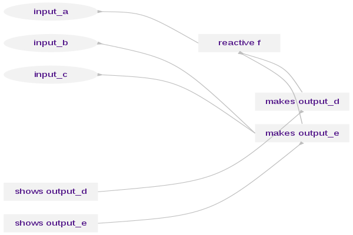

Ici on a introduit une **réactive** f().

Ici encore, vous trouverez un exemple d’une telle structure d’appli (à droite).

La réactive **f()** sert ici à créer le chemin de l’image à partir de l’input (“heart” ou “sun”). Les deux ouptuts utilisent cette fonction pour afficher l’image correspondante.

ui

```r
  fluidRow(column(width=4,radioButtons("A","Image:", c("heart","sun"))),
           column(width=4,radioButtons("B","Word 1:", c("Hello","Greetings"))),
           column(width=4,radioButtons("C","Word 2:", c("Master","Human")))),
  tabsetPanel(selected="tab2",
              tabPanel("tab1",uiOutput("D")),
              tabPanel("tab2",uiOutput("E")))
```

server

```r
  f=reactive({
    Sys.sleep(1)
    result=paste0("www/",input$A,".png")
  })
  output$D <- renderUI({img(src=f())})
  output$E <- renderUI({p(img(src=f())," ",input$B,",",input$C,"!")})
```

[interactive chart not shown]

Ici, la seconde de “pause” intervient quand la réactive est exécutée. Remarquez que quand vous changez de tab, la réactive n’est pas réexécutée… La réactive est réexécutée seulement quand son input est modifié!

# Provoquer/retarder l’exécution: utilisation des triggers

Dans le mécanisme de réactivité le plus classique, un code est exécuté quand il correspond à un output “attentif” et que l’un de ses inputs est modifié.

Il est possible de contourner ce mécanisme et de faire en sorte que l’exécution d’un code soit **déclenché par l’utilisateur**.

Ce genre de mécanisme va de pair avec l’utilisation des widgets de type “trigger”:

[figure not shown]

# Déclencher/provoquer l’exécution d’un code

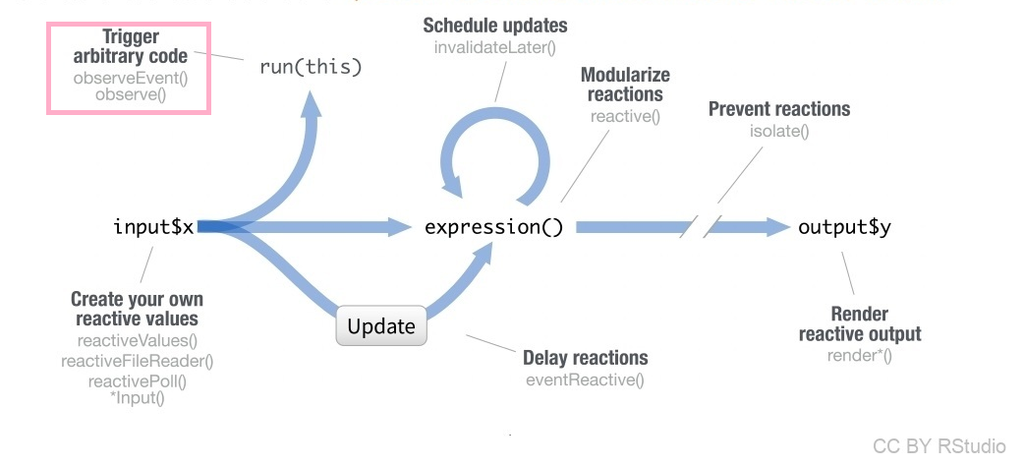

Dans ce cas, le code exécuté **ne correspond pas à un output de l’appli**. Il peut s’agir d’un code permettant par exemple:

- l’écriture d’un fichier (tableau de données, figure, raster, etc.)
- l’affichage d’un résultat (`print(...)`) dans la console
- un update de widget

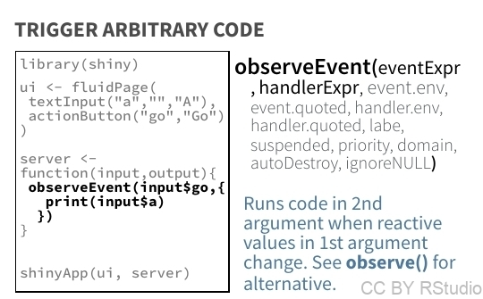

ui

```r
actionButton("go","go!")
```

server

```r
observeEvent(input$go,{
  updateActionButton(session,
                     inputId="go",
                     label=str_c(str_c(rep("go",input$go+1),
                                       collapse=", "),
                                 "!")
                     )
})
```

[interactive chart not shown]

# Déclencher/retarder une réaction

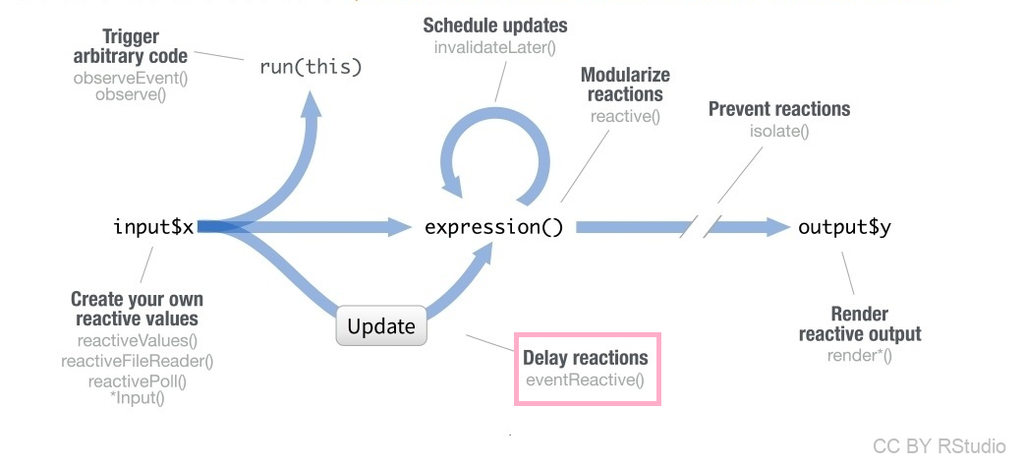

Dans ce cas, le code est exécuté **non pas dès que l’un de ses inputs est modifié, mais lorsque que l’utilisateur déclenche la réaction**.

Le fait pour l’utilisateur de valider l’exécution d’un code permet notamment de gérer l’exécution de codes un peu trop longs pour une “instantanéité” d’affichage des résultats.

[figure not shown]

```r
actionButton("now","Now!"),
textOutput("time")
```

```r
reac=eventReactive(input$now,{
  as.character(Sys.time())
})
output$time=renderText({
  str_c("The time right now is: ",reac())
  })
```

[interactive chart not shown]

# Empêcher des réactions

[figure not shown]

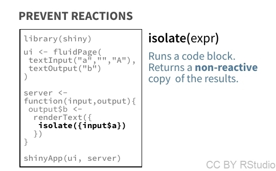

```r
fluidRow(column(width=4,textInput("word1","First word","Hello")),
         column(width=4,textInput("word2","Second word","Master")),
         column(width=4,textOutput("combi"))
)
```

```r
output$combi <- renderText({paste(input$word1,isolate(input$word2))})
```

```r
output$combi <- renderText({paste(input$word1,isolate(input$word2))})
```

[interactive chart not shown]